# Practical Machine Learning Project

Jose Gonzalez

31 décembre 2016

# Introduction

The purpose of this project is to conceive a model to predict the type of performed activity based on a set of data coming from different sensors. More information is available from the website here: http://groupware.les.inf.puc-rio.br/har (see the section on the Weight Lifting Exercise Dataset).

# Getting and cleaning data

The data was downloaded from the following sources:

- Training: https://d396qusza40orc.cloudfront.net/predmachlearn/pml-training.csv
- Testing: https://d396qusza40orc.cloudfront.net/predmachlearn/pml-testing.csv

We load the datasets into R

```r
training<-read.csv("pml-training.csv")
testing<-read.csv("pml-testing.csv")
```

## Exploratory data analysis

We can have a quick look at the training set, to assess it size and get the number of variables.

```r
dim(training)
```

```
## [1] 19622   160
```

```r
str(training, list.len=30)
```

```
## 'data.frame':    19622 obs. of  160 variables:
##  $ X                       : int  1 2 3 4 5 6 7 8 9 10 ...
##  $ user_name               : Factor w/ 6 levels "adelmo","carlitos",..: 2 2 2 2 2 2 2 2 2 2 ...
##  $ raw_timestamp_part_1    : int  1323084231 1323084231 1323084231 1323084232 1323084232 1323084232 1323084232 1323084232 1323084232 1323084232 ...
##  $ raw_timestamp_part_2    : int  788290 808298 820366 120339 196328 304277 368296 440390 484323 484434 ...
##  $ cvtd_timestamp          : Factor w/ 20 levels "02/12/2011 13:32",..: 9 9 9 9 9 9 9 9 9 9 ...
##  $ new_window              : Factor w/ 2 levels "no","yes": 1 1 1 1 1 1 1 1 1 1 ...
##  $ num_window              : int  11 11 11 12 12 12 12 12 12 12 ...
##  $ roll_belt               : num  1.41 1.41 1.42 1.48 1.48 1.45 1.42 1.42 1.43 1.45 ...
##  $ pitch_belt              : num  8.07 8.07 8.07 8.05 8.07 8.06 8.09 8.13 8.16 8.17 ...
##  $ yaw_belt                : num  -94.4 -94.4 -94.4 -94.4 -94.4 -94.4 -94.4 -94.4 -94.4 -94.4 ...
##  $ total_accel_belt        : int  3 3 3 3 3 3 3 3 3 3 ...
##  $ kurtosis_roll_belt      : Factor w/ 397 levels "","-0.016850",..: 1 1 1 1 1 1 1 1 1 1 ...
##  $ kurtosis_picth_belt     : Factor w/ 317 levels "","-0.021887",..: 1 1 1 1 1 1 1 1 1 1 ...
##  $ kurtosis_yaw_belt       : Factor w/ 2 levels "","#DIV/0!": 1 1 1 1 1 1 1 1 1 1 ...
```

[output cut: 17 more lines]

```r
table(training$classe)
```

```
##
##    A    B    C    D    E
## 5580 3797 3422 3216 3607
```

## Data Cleaning

The first 7 variables appear to be “administrative” information. It seems very unlikely that these can bring information about the type of activity being performed. The rest of te variables do appear to contain sensor based information that might be relevant for deriving the activity being performed.

```r
training <- training[, 8:160]
testing  <- testing[, 8:160]
```

Remove columns which have more than 50% of N/A values. We estimate just a low rate of valid value should not be able to bring much to the prediction algorithm.

```r
is_data  <- apply(!is.na(training), 2, sum) > length(training[,1])*0.5
training <- training[, is_data]
testing  <- testing[, is_data]
```

# Prediction Model

## Partitioning of training data

We partition the training set in order to be able to do cross-validation. The partition is based on the classe variable with 60% retained for training and 40% for crossvalidation.

```r
library(caret)
set.seed(3141592)
inTrain <- createDataPartition(y=training$classe, p=0.60, list=FALSE)
train1  <- training[inTrain,]
train2  <- training[-inTrain,]
dim(train1)
```

```
## [1] 11776    86
```

## Removal of near zero covariates

We will also remove the “near zero covariates”

```r
nzv_cols <- nearZeroVar(train1)
if(length(nzv_cols) > 0) {
  train1 <- train1[, -nzv_cols]
  train2 <- train2[, -nzv_cols]
}
dim(train1)
```

```
## [1] 11776    53
```

## Quick model for assessing variable importance

We will try through a quick random forest classification to have an estimation of the variable importance

[figure not shown]

```r
library(randomForest)
set.seed(3141592)
fitModel <- randomForest(classe~., data=train1, importance=TRUE, ntree=100)
varImpPlot(fitModel)
```

We select the 10 first variables with most importance

```r
importance<-fitModel$importance
importance<-importance[order(-importance[,6]),]
rownames(importance[1:10,])
```

```
##  [1] "roll_belt"         "roll_forearm"      "magnet_dumbbell_z"
##  [4] "magnet_dumbbell_y" "yaw_belt"          "magnet_dumbbell_x"
##  [7] "pitch_belt"        "pitch_forearm"     "roll_dumbbell"
## [10] "magnet_belt_z"
```

As an example, we can plot the classe on the training set based on the two most important variables. The plot shows that a quick classification can be done based on just these two variables.

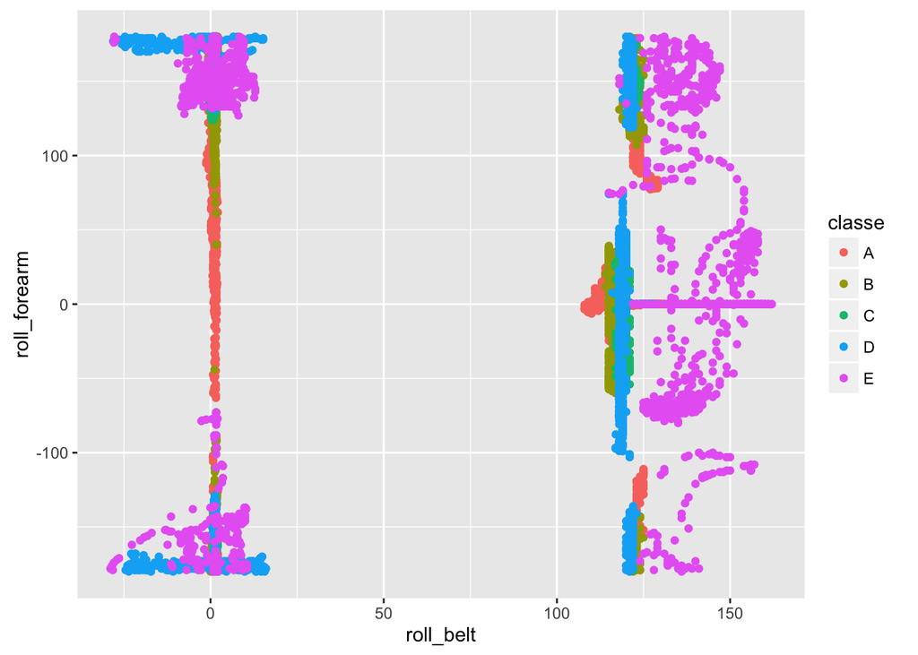

```r
qplot(roll_belt, roll_forearm, colour=classe, data=train1)
```

And we can show a feature plot, limited to the first 3 variables (for readability purposes)

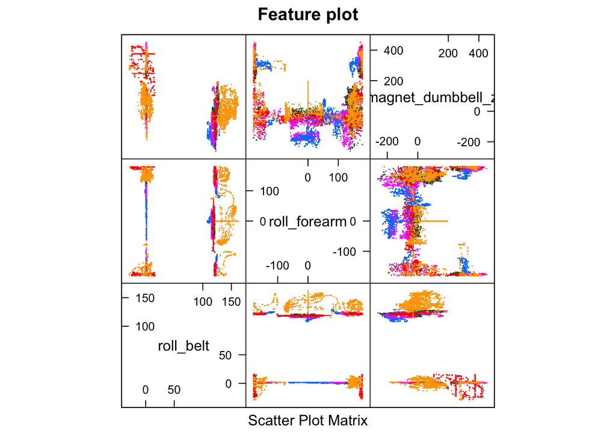

```r
featurePlot(x = train1[,rownames(importance[1:3,])], y = train1$classe, pch = ".", main = "Feature plot",plot="pairs")
```

We now create a formula with those variables

```r
myFormula<-paste(rownames(importance[1:10,]),collapse="+")
myFormula<-paste("classe~",myFormula,sep="")
myFormula
```

```
## [1] "classe~roll_belt+roll_forearm+magnet_dumbbell_z+magnet_dumbbell_y+yaw_belt+magnet_dumbbell_x+pitch_belt+pitch_forearm+roll_dumbbell+magnet_belt_z"
```

## Final model

Based on the formula derived from variable importance in the previous section, we can create a more complex (with more iterations and trees) random forest model.

```r
set.seed(3141592)
fitModel <- train(as.formula(myFormula),
                  data=train1,
                  method="rf",
                  trControl=trainControl(method="cv",number=2),
                  prox=TRUE,
                  verbose=TRUE,
                  allowParallel=TRUE)
```

# Cross-Validation

## Prediction quality on training set

```r
predictions <- predict(fitModel, newdata=train1)
confusionMat <- confusionMatrix(predictions, train1$classe)
confusionMat
```

```
## Confusion Matrix and Statistics
##
##           Reference
## Prediction    A    B    C    D    E
##          A 3348    0    0    0    0
##          B    0 2279    0    0    0
##          C    0    0 2054    0    0
##          D    0    0    0 1930    0
##          E    0    0    0    0 2165
##
## Overall Statistics
##
##                Accuracy : 1
##                  95% CI : (0.9997, 1)
##     No Information Rate : 0.2843
##     P-Value [Acc > NIR] : < 2.2e-16
##
##                   Kappa : 1
##  Mcnemar's Test P-Value : NA
##
## Statistics by Class:
##
##                      Class: A Class: B Class: C Class: D Class: E
## Sensitivity            1.0000   1.0000   1.0000   1.0000   1.0000
## Specificity            1.0000   1.0000   1.0000   1.0000   1.0000
## Pos Pred Value         1.0000   1.0000   1.0000   1.0000   1.0000
## Neg Pred Value         1.0000   1.0000   1.0000   1.0000   1.0000
## Prevalence             0.2843   0.1935   0.1744   0.1639   0.1838
## Detection Rate         0.2843   0.1935   0.1744   0.1639   0.1838
## Detection Prevalence   0.2843   0.1935   0.1744   0.1639   0.1838
## Balanced Accuracy      1.0000   1.0000   1.0000   1.0000   1.0000
```

Prediction is perfect on training set, despite having only retained 10 covariates for the prediction.

## Prediction quality on validation set

```r
predictions <- predict(fitModel, newdata=train2)
confusionMat <- confusionMatrix(predictions, train2$classe)
confusionMat
```

```
## Confusion Matrix and Statistics
##
##           Reference
## Prediction    A    B    C    D    E
##          A 2222   15    1    2    1
##          B    3 1471   15    2   16
##          C    5   21 1340   18    6
##          D    1   11   12 1263    3
##          E    1    0    0    1 1416
##
## Overall Statistics
##
##                Accuracy : 0.9829
##                  95% CI : (0.9798, 0.9857)
##     No Information Rate : 0.2845
##     P-Value [Acc > NIR] : < 2.2e-16
##
##                   Kappa : 0.9784
##  Mcnemar's Test P-Value : 6.284e-06
##
## Statistics by Class:
##
##                      Class: A Class: B Class: C Class: D Class: E
## Sensitivity            0.9955   0.9690   0.9795   0.9821   0.9820
## Specificity            0.9966   0.9943   0.9923   0.9959   0.9997
## Pos Pred Value         0.9915   0.9761   0.9640   0.9791   0.9986
## Neg Pred Value         0.9982   0.9926   0.9957   0.9965   0.9960
## Prevalence             0.2845   0.1935   0.1744   0.1639   0.1838
## Detection Rate         0.2832   0.1875   0.1708   0.1610   0.1805
## Detection Prevalence   0.2856   0.1921   0.1772   0.1644   0.1807
## Balanced Accuracy      0.9961   0.9817   0.9859   0.9890   0.9908
```

Prediction on validation set has a 98.2% accuracy.

# Estimation of the expected out of sample error

The estimated out of sample error is 1.7%

```r
1-confusionMat$overall[1] #1-accuracy
```

```
##   Accuracy
## 0.01707877
```

# Prediction on test set

```r
predictions<-predict(fitModel,newdata = testing)
predictions
```

```
##  [1] B A B A A E D B A A B C B A E E A B B B
## Levels: A B C D E
```